# Using Childhood and Adulthood Stress Factors as Predictors for Nicotine Use

BMIN503/EPID600 Final Project

Author

Katie Cardone

### Overview

Cigarette smoking use is a major health problem in the United States, as it is the leading cause of preventable death. Many family-related problems/stress have been associated with smoking individually, but this study considers whether the combination of these risk factors using a machine learning approach can improve prediction. This study also investigates the individual relationships between the predictors and nicotine use status as well as correlations between the predictors to understand the mechanisms in which these predictors interact with each other or contribute to nicotine use. This study will leverage data from the Behavioral Risk Factor Surveillance System 2022 survey, as this provides data on both family risk factors and nicotine use.

Link to github repository: [Github Repository](https://github.com/katiecardone26/BMIN503_Final_Project)

### Introduction

Cigarette smoking is the leading cause of preventable mortality<sup>1</sup>. 480,000 deaths per year in the United States are due to smoking<sup>2</sup> and smokers die on average 10 years earlier compared to non-smokers<sup>3</sup>. Stress is a risk factor for smoking, as greater stress is associated with a higher odds of persistent smoking<sup>4</sup>. This includes family problems in the past year, which is particularly important as family problems doubles the odds of quitting failure<sup>4</sup>. Many studies have shown that a variety of family problems/stress factors in the home are associated with an increased prevalence of smoking. In one study, 81% of tobacco users had a family history of tobacco use<sup>5</sup>. Additionally, individuals with a history of child abuse are more likely to become smokers as adults<sup>6</sup>. More specifically, child sexual abuse predicted adolescent smoking frequency<sup>7</sup>. Maltreatment in childhood, including neglect and failure of caregivers to provide for child, is associated with smoking in adulthood<sup>8</sup>. Another study showed that substance use, including tobacco, was associated with past and present parental incarceration<sup>9</sup>. Parental divorce or separation in childhood was also associated with smoking in adulthood<sup>10</sup>.

Evidently, smoking is a major health problem and family issues individually seem to predict it. However, this project assesses whether the combination of these factors can better predict nicotine use. To properly create a model that answers this question, an interdisciplinary approach is most beneficial. This is a public health issue, so epidemiologists will provide insight on factors to consider when answering this question. Additionally, the outcome of interest is substance use, so psychiatrists can also provide useful knowledge. Last, this project will utilize a machine learning method, so computational biologists can provide insight on how to optimize the model. Given the interdisciplinary nature of this project, I spoke to Dr. Marylyn Ritchie, a professor in the Department of Genetics and Director of the Institute for Biomedical Informatics at Penn, and Dr. Jim Guevera, a professor of Pediatrics in the Division of General Pediatrics at CHOP, for insight. From Dr. Ritchie, I learned about the importance of removing individuals with missing values in any variable from a machine learning model. I also learned that I should have as many predictors as I can in the machine learning model. Given this, I have 16 predictors because including more would significantly drop the sample size when removing individuals with missing values. From Dr. Guevera, I learned that adverse childhood experiences are good predictors to answer my question, so I included many of them in my model. Additionally, to reduce missingness, I combined all adverse childhood experience questions relating to molestation into one variable, but Dr. Guevera suggested that I include these variables separately and together as that would improve the model, so I did that as well. He also suggested to include socioeconomic status in the model, so I added variable indicating if one’s annual household income was less than $25,000.

### Methods

#### Loading Packages

The packages needed for this project are tidyverse, haven, modelr, randomForest, vip, tidymodels, and ggplot2.

```r
# tidyverse package
library(tidyverse)
# haven package
library(haven)
# modelr package
library(modelr)
# random forest package
library(randomForest)
# VIP package
library(vip)
# tidymodels package
library(tidymodels)
# ggplot package
library(ggplot2)
# model summary package
library(modelsummary)
# ggcorrplot package
library(ggcorrplot)
```

#### Downloading Data

The 2022 BRFSS data will be used for this analysis.

```r
# Load in data
brfss_raw <- as.tibble(read_xpt("LLCP2022.XPT"))
head(brfss_raw)
```

```
# A tibble: 6 × 326
  `_STATE` FMONTH IDATE    IMONTH IDAY  IYEAR DISPCODE SEQNO     `_PSU` CTELENM1
     <dbl>  <dbl> <chr>    <chr>  <chr> <chr>    <dbl> <chr>      <dbl>    <dbl>
1        1      1 02032022 02     03    2022      1100 20220000… 2.02e9        1
2        1      1 02042022 02     04    2022      1100 20220000… 2.02e9        1
3        1      1 02022022 02     02    2022      1100 20220000… 2.02e9        1
4        1      1 02032022 02     03    2022      1100 20220000… 2.02e9        1
5        1      1 02022022 02     02    2022      1100 20220000… 2.02e9        1
6        1      1 02112022 02     11    2022      1100 20220000… 2.02e9        1
# ℹ 316 more variables: PVTRESD1 <dbl>, COLGHOUS <dbl>, STATERE1 <dbl>,
#   CELPHON1 <dbl>, LADULT1 <dbl>, COLGSEX1 <dbl>, NUMADULT <dbl>,
#   LANDSEX1 <dbl>, NUMMEN <dbl>, NUMWOMEN <dbl>, RESPSLCT <dbl>,
#   SAFETIME <dbl>, CTELNUM1 <dbl>, CELLFON5 <dbl>, CADULT1 <dbl>,
#   CELLSEX1 <dbl>, PVTRESD3 <dbl>, CCLGHOUS <dbl>, CSTATE1 <dbl>,
#   LANDLINE <dbl>, HHADULT <dbl>, SEXVAR <dbl>, GENHLTH <dbl>, PHYSHLTH <dbl>,
#   MENTHLTH <dbl>, POORHLTH <dbl>, PRIMINSR <dbl>, PERSDOC3 <dbl>, …
```

#### Cleaning Data

The BRFSS dataframe will be subset to the variables that will used in the analysis. Only adults (age >=18) will be included in this study because I want to include both adulthood and childhood risk factors in the study. The outcome of interest is nicotine use status. If an individual uses cigarettes, e-cigarettes, or other forms of nicotine at all, they are considered a nicotine user. Predictors include:

- sex
- days in a month of bad mental health
- annual household income less than $25,000
- caregiver status
- lived with someone who was depressed, mentally ill, or suicidal as a child
- lived with an alcoholic or problem drinker as a child
- lived with an illicit substance user or prescription substance abuser as child
- lived with someone who was incarcerated as a child
- had parents who were separated or divorced
- had parents that sweared at them as a child
- was abused, neglected or molested as a child

Most variables will be recoded such that they are binary variables (yes or no). Multiple molestation columns will be combined into one to reduce missingness. Individuals with a missing value in any column will be dropped.

```r
# subset to columns I need
brfss_clean <- brfss_raw |>
  select(LADULT1,COLGSEX1,CADULT1,CELLSEX1,MENTHLTH,INCOME3,SMOKDAY2,USENOW3,ECIGNOW2,CAREGIV1,ACEDEPRS,ACEDRINK,ACEDRUGS,ACEPRISN,ACEDIVRC,ACEHURT1,ACESWEAR,ACETOUCH,ACETTHEM,ACEHVSEX,ACEADNED)

# rename columns
brfss_clean <- rename(brfss_clean,adult_landline=LADULT1,
                      sex_landline=COLGSEX1,
                      adult_cell=CADULT1,
                      sex_cell=CELLSEX1,
                      days_mental_health_bad_past_month=MENTHLTH,
                      income_less_25K=INCOME3,
                      cigs_day_freq=SMOKDAY2,
                      other_forms_tobacco_day_freq=USENOW3,
                      ecigs_day_freq=ECIGNOW2,
                      caregiver_past_month=CAREGIV1,
                      lived_with_depressed_mentally_ill_or_suicidial=ACEDEPRS,
                      lived_with_alcoholic=ACEDRINK,
                      lived_with_hard_drug_user=ACEDRUGS,
                      lived_with_convict=ACEPRISN,
                      parents_separated_or_divorced=ACEDIVRC,
                      parents_hurt_you_freq=ACEHURT1,
                      parents_swear_at_you_freq=ACESWEAR,
                      sexual_touch_you_freq=ACETOUCH,
                      force_touch_others_sexually=ACETTHEM,
                      force_sex_freq=ACEHVSEX,
                      basic_needs_met_by_adult_amount_childhood=ACEADNED)


# combine adult landline and adult cell columns
brfss_clean <- brfss_clean %>%
  mutate(adult=paste0(adult_landline,adult_cell))
# filter dataframe to only include adults
brfss_clean <- brfss_clean %>%
  filter(grepl('1NA|NA1|11',adult))

# recode columns
# combine landline and cell sex columns
# 1 = male, 0 = female, NA = missing
brfss_clean <- brfss_clean %>%
  mutate(sex=paste0(sex_landline,sex_cell))
brfss_clean$sex <- case_match(brfss_clean$sex,
                           c('1NA','NA1',11) ~ 1,
                           c('2NA','NA2',22) ~ 0,
                           'NANA' ~ NA)

# clean mental health column
# 0-30 = number of days with bad mental health, NA=missing
brfss_clean$days_mental_health_bad_past_month <- case_match(brfss_clean$days_mental_health_bad_past_month,
                                                         1 ~ 1,
                                                         2 ~ 2,
                                                         3 ~ 3,
                                                         4 ~ 4,
                                                         5 ~ 5,
                                                         6 ~ 6,
                                                         7 ~ 7,
                                                         8 ~ 8,
                                                         9 ~ 9,
                                                         10 ~ 10,
                                                         11 ~ 11,
                                                         12 ~ 12,
                                                         13 ~ 13,
                                                         14 ~ 14,
                                                         15 ~ 15,
                                                         16 ~ 16,
                                                         17 ~ 17,
                                                         18 ~ 18,
                                                         19 ~ 19,
                                                         20 ~ 20,
                                                         21 ~ 21,
                                                         22 ~ 22,
                                                         23 ~ 23,
                                                         24 ~ 24,
                                                         25 ~ 25,
                                                         26 ~ 26,
                                                         27 ~ 27,
                                                         28 ~ 28,
                                                         29 ~ 29,
                                                         30 ~ 30,
                                                         c(77,99) ~ NA,
                                                         88 ~ 0)

# clean income column
brfss_clean$income_less_25K <- case_match(brfss_clean$income_less_25K,
                                          1 ~ 1,
                                          2 ~ 1,
                                          3 ~ 1,
                                          4 ~ 1,
                                          5 ~ 0,
                                          6 ~ 0,
                                          7 ~ 0,
                                          8 ~ 0,
                                          9 ~ 0,
                                          10 ~ 0,
                                          11 ~ 0,
                                          77 ~ NA,
                                          99 ~ NA)

# clean cigs_day_freq column
# 1 = every day or some days, 0 = not at all, NA = missing, no answer or inconclusive answer
brfss_clean$cigs_day_freq <- case_match(brfss_clean$cigs_day_freq,
                                     1 ~ 1,
                                     2 ~ 1,
                                     3 ~ 0,
                                     c(7,9) ~ NA)

# clean other_forms_tobacco_day_freq column
# 1 = every day or some days, 0 = not at all, NA = missing, no answer or inconclusive answer
brfss_clean$other_forms_tobacco_day_freq <- case_match(brfss_clean$other_forms_tobacco_day_freq,
                                                    1 ~ 1,
                                                    2 ~ 1,
                                                    3 ~ 0,
                                                    c(7,9) ~ NA)

# clean ecigs_day_freq column
# 1 = use them every day or some days, 0 = never or not right now, NA = missing, no answer or inconclusive answer
brfss_clean$ecigs_day_freq <- case_match(brfss_clean$ecigs_day_freq,
                                c(1,4) ~ 0,
                                c(2,3) ~ 1,
                                c(7,9) ~ NA)
```

```r
# clean caregiver_past_month columns
# 1 = yes or person caring for died in the past 30 days (need to see if those people answered subsequent questions), 0 = no, NA = missing, no answer or inconclusive answer
# need to make one caregiver score?
# maybe include employment status in this to see if it is interferring with work?
brfss_clean$caregiver_past_month <- case_match(brfss_clean$caregiver_past_month,
                                            1 ~ 1,
                                            2 ~ 0,
                                            c(7,9) ~ NA,
                                            8 ~ 1)

# clean lived_with_depressed_mentally_ill_or_suicidial column
# 1 = yes, 0 = no, NA = missing, no answer, or inconclusive answer
brfss_clean$lived_with_depressed_mentally_ill_or_suicidial <- case_match(brfss_clean$lived_with_depressed_mentally_ill_or_suicidial,
                                                                      1 ~ 1,
                                                                      2 ~ 0,
                                                                      c(7,9) ~ NA)

# clean lived_with_alcoholic column
# 1 = yes, 0 = no, NA = missing, no answer, or inconclusive answer
brfss_clean$lived_with_alcoholic <- case_match(brfss_clean$lived_with_alcoholic,
                                            1 ~ 1,
                                            2 ~ 0,
                                            c(7,9) ~ NA)

# clean lived_with_hard_drug_user column
# 1 = yes, 0 = no, NA = missing, no answer, or inconclusive answer
brfss_clean$lived_with_hard_drug_user <- case_match(brfss_clean$lived_with_hard_drug_user,
                                                 1 ~ 1,
                                                 2 ~ 0,
                                                 c(7,9) ~ NA)

# clean lived_with_convict column
# 1 = yes, 0 = no, NA = missing, no answer, or inconclusive answer
brfss_clean$lived_with_convict <- case_match(brfss_clean$lived_with_convict,
                                          1 ~ 1,
                                          2 ~ 0,
                                          c(7,9) ~ NA)

# clean parents_separated_or_divorced column
# 1 = yes, 0 = no, NA = missing, no answer, or inconclusive answer
brfss_clean$parents_separated_or_divorced <- case_match(brfss_clean$parents_separated_or_divorced,
                                                     1 ~ 1,
                                                     2 ~ 0,
                                                     c(7,9) ~ NA)

# clean parents_hurt_you_freq column
# 1 = once or more than once, 0 = never, NA = missing, no answer, or inconclusive answer
brfss_clean$parents_hurt_you_freq <- case_match(brfss_clean$parents_hurt_you_freq,
                                             1 ~ 0,
                                             c(2,3) ~ 1,
                                             c(7,9) ~ NA)

# clean parents_swear_at_you_freq column
# 1 = once or more than once, 0 = never, NA = missing, no answer, or inconclusive answer
brfss_clean$parents_swear_at_you_freq <- case_match(brfss_clean$parents_swear_at_you_freq,
                                                 1 ~ 0,
                                                 c(2,3) ~ 1,
                                                 c(7,9) ~ NA)

# clean sexual_touch_you_freq column
# 1 = once or more than once, 0 = never, NA = missing, no answer, or inconclusive answer
# maybe integrate with other molesting columns
brfss_clean$sexual_touch_you_freq <- case_match(brfss_clean$sexual_touch_you_freq,
                                             1 ~ 0,
                                             c(2,3) ~ 1,
                                             c(7,9) ~ NA)

# clean force_touch_others_sexually column
# 1 = once or more than once, 0 = never, NA = missing, no answer, or inconclusive answer
# maybe integrate with other molesting columns
# turned freq column into a yes or no column
brfss_clean$force_touch_others_sexually <- case_match(brfss_clean$force_touch_others_sexually,
                                                      1 ~ 0,
                                                      c(2,3) ~ 1,
                                                      c(7,9) ~ NA)

# clean force_sex_freq column
# 1 = once or more than once, 0 = never, NA = missing, no answer, or inconclusive answer
# maybe integrate with other molesting columns
# turned freq column into a yes or no column
brfss_clean$force_sex_freq <- case_match(brfss_clean$force_sex_freq,
                                      1 ~ 0,
                                      c(2,3) ~ 1,
                                      c(7,9) ~ NA)

# clean basic_needs_met_by_adult_amount_childhood column
# 1 = never, 2 = little, 3 = some, 4 = most, 5 = all, NA = missing, no answer, or inconclusive answer
# maybe make this into a hard score
brfss_clean$basic_needs_met_by_adult_amount_childhood <- case_match(brfss_clean$basic_needs_met_by_adult_amount_childhood,
                                                                 1 ~ 1,
                                                                 2 ~ 2,
                                                                 3 ~ 3,
                                                                 4 ~ 4,
                                                                 5 ~ 5,
                                                                 c(7,9) ~ NA)

# create molesting column
# 1: answered yes to at least one of the questions, 0: answered no or missing to all the questions, NA: all questions missing
brfss_clean <- brfss_clean %>%
  mutate(molestation = paste0(sexual_touch_you_freq,force_touch_others_sexually,force_sex_freq))
brfss_clean$molestation <- case_match(brfss_clean$molestation,
                                      c('100','110','101','010','011','001','111','1NANA','NA1NA','11NA','NANA1','1NA1','NA11','10NA','NA01','0NA1','NA10','1NA0','01NA') ~ 1,
                                      c('000','0NA0','0NANA','NANA0','NA00','00NA','NA0NA') ~ 0,
                                      'NANANA' ~ NA)
```

```r
# create smoking column
# 1: answered yes to at least one of the questions, 0: answereing no or missing to all questions, NA: all questions missing
brfss_clean <- brfss_clean %>%
  mutate(smoking=paste0(cigs_day_freq,other_forms_tobacco_day_freq,ecigs_day_freq))
brfss_clean$smoking <- case_match(brfss_clean$smoking,
                                  c('100','010','001','NA01','NA10','NA11','1NA1','110','011','101','NANA1','1NA0','0NA1','NA1NA','1NANA','111','10NA','11NA','01NA') ~ 1,
                                  c('NA00','000','NANA0','0NA0','NA0NA','00NA','0NANA') ~ 0,
                                  'NANANA' ~ NA)

# remove unneeded columns
brfss_clean <- brfss_clean %>%
  select(-adult_landline,-sex_landline,-adult_cell,-sex_cell,-cigs_day_freq,-other_forms_tobacco_day_freq,-ecigs_day_freq,-adult)

# drop nas
brfss_clean_no_missing <- brfss_clean %>%
  drop_na()

# convert smoking column (outcome) to factor
brfss_clean_no_missing$smoking=as.factor(brfss_clean_no_missing$smoking)

# get total sample size
nrow(brfss_clean_no_missing)
```

```
[1] 6741
```

There are 6741 individuals in the model after cleaning.

#### Build and Run Random Forest Model

I am using a random forest model to combine the predictors and predict the outcome. I chose to use a random forest model because I am attempting to use the predictors to properly classify nicotine users vs. non-nicotine users. To test for overfitting, I will be building the model with and without 10-fold cross validation.

```r
# set seed
set.seed(1234)

# set random forest specs
rf_spec <-
  rand_forest(trees = 1000, min_n = 5) |>
  set_engine("randomForest", importance = TRUE) |>
  set_mode("classification")

# split dataset 80% train 20% test
brfss.split <- initial_split(brfss_clean_no_missing,
                            strata = smoking,
                            prop = 0.80)

# create training dataset
brfss.train <- training(brfss.split)

# split dataset for 10 fold cross validation
brfss.training.folds <- vfold_cv(brfss.train, v = 10)

# create rf workflow
rf_workflow <-
  workflow() |>
  add_model(rf_spec) |>
  add_formula(smoking ~ .)

# fit model with cross validation
brfss.rf.pred.values.crossval <-
  rf_workflow |>
  fit_resamples(brfss.training.folds,
                control = control_resamples(save_pred = TRUE))

# fit model without cross validation
brfss.rf.predicted.nocrossval <- rf_spec |>
  fit(smoking ~ ., data = brfss_clean_no_missing)

# extract predicted values
brfss.rf.pred.values.nocrossval <-  bind_cols(
  truth = brfss_clean_no_missing$smoking,
  predict(brfss.rf.predicted.nocrossval, brfss_clean_no_missing),
  predict(brfss.rf.predicted.nocrossval, brfss_clean_no_missing, type = "prob"))
```

### Run Univariate Logistic Regressions Between Each Predictor and Nicotine Use Status to Assess Impacts of Individual Predictors

To assess the impact of individual predictors and nicotine use status, I am going to run a univariate logistic regression between each predictor and nicotine use status. This will be a good comparison with the combination of all predictors in the random forest model.

```r
# logistic regression between days of bad mental health in the past month and nicotine use status
mental_health_glm <- glm(smoking ~ days_mental_health_bad_past_month, data = brfss_clean_no_missing, family = binomial())

# logistic regression between annual household income less than $25,000 and nicotine use status
income_less_25K_glm <- glm(smoking ~ income_less_25K, data = brfss_clean_no_missing, family = binomial())

# logistic regression between providing care to another person in the past month and nicotine use status
caregiver_glm <- glm(smoking ~ caregiver_past_month, data = brfss_clean_no_missing, family = binomial())

# logistic regression between lived with someone who was depressed, mentall ill, or suicidal as a child and nicotine use status
lived_with_depressed_mentally_ill_or_suicidial_glm <- glm(smoking ~ lived_with_depressed_mentally_ill_or_suicidial, data = brfss_clean_no_missing, family = binomial())

# logistic regression between lived with alcoholic or problem drinker as a child and nicotine use status
lived_with_alcoholic_glm <- glm(smoking ~ lived_with_alcoholic, data = brfss_clean_no_missing, family = binomial())

# logistic regression between lived with an illicit substance user or prescription drug abuser as a child and nicotine use status
lived_with_hard_drug_user_glm <- glm(smoking ~ lived_with_hard_drug_user, data = brfss_clean_no_missing, family = binomial())

# logistic regression between lived with someone who was incarcerated as a child and nicotine use status
lived_with_convict_glm <- glm(smoking ~ lived_with_convict, data = brfss_clean_no_missing, family = binomial())

# logistic regression between parental separation or divorce as a child and nicotine use status
parents_separated_or_divorced_glm <- glm(smoking ~ parents_separated_or_divorced, data = brfss_clean_no_missing, family = binomial())

# logistic regression between physical abuse as a child and nicotine use status
parents_hurt_you_freq_glm <- glm(smoking ~ parents_hurt_you_freq, data = brfss_clean_no_missing, family = binomial())

# logistic regression between being sweared at by parents as a child and nicotine use status
parents_swear_at_you_freq_glm <- glm(smoking ~ parents_swear_at_you_freq, data = brfss_clean_no_missing, family = binomial())

# logistic regression between being touched sexually as a child and nicotine use status
sexual_touch_you_freq_glm <- glm(smoking ~ sexual_touch_you_freq, data = brfss_clean_no_missing, family = binomial())

# logistic regression between being forced to touch another person sexually as a child and nicotine use status
force_touch_others_sexually_glm <- glm(smoking ~ force_touch_others_sexually, data = brfss_clean_no_missing, family = binomial())

# logistic regression between being forced to have sex as a child and nicotine use status
force_sex_freq_glm <- glm(smoking ~ force_sex_freq, data = brfss_clean_no_missing, family = binomial())

# logistic regression between basic needs met by an adult as a child and nicotine use status
basic_needs_met_by_adult_amount_childhood_glm <- glm(smoking ~ basic_needs_met_by_adult_amount_childhood, data = brfss_clean_no_missing, family = binomial())

# logistic regression between sex and nicotine use status
sex_glm <- glm(smoking ~ sex, data = brfss_clean_no_missing, family = binomial())

# logistic regression between all forms of molestation and nicotine use status
molestation_glm <- glm(smoking ~ molestation, data = brfss_clean_no_missing, family = binomial())
```

### Assess Correlations Between Predictors

To assess relationships between the predictors to understand how they may be interacting in the random forest model, I am going to calculate the correlations between all of them. I chose to use a Spearman correlation because some of the variables may not have a normal distribution.

```r
# create correlation matrix
predictor_cor=cor(brfss_clean_no_missing[,c('sex',
                                            'days_mental_health_bad_past_month',
                                            'income_less_25K',
                                            'caregiver_past_month',
                                            'lived_with_depressed_mentally_ill_or_suicidial',
                                            'lived_with_alcoholic',
                                            'lived_with_hard_drug_user',
                                            'lived_with_convict',
                                            'parents_separated_or_divorced',
                                            'parents_hurt_you_freq',
                                            'parents_swear_at_you_freq',
                                            'sexual_touch_you_freq',
                                            'force_touch_others_sexually',
                                            'force_sex_freq',
                                            'molestation',
                                            'basic_needs_met_by_adult_amount_childhood')],
                  use = "complete.obs", method = "spearman")

# rename columns for plot
colnames(predictor_cor) = c('sex',
                            'mental_health',
                            'SES',
                            'mentally_ill',
                            'caregiver',
                            'alcoholic',
                            'hard_drug_user',
                            'incarceration',
                            'parental_separation',
                            'physical_abuse',
                            'sweared_at',
                            'touched_sexually',
                            'touched_another_sexually',
                            'forced_sex',
                            'combined_molestation',
                            'maltreatment')

# rename rows for plot
rownames(predictor_cor) = c('sex',
                            'mental_health',
                            'SES',
                            'mentally_ill',
                            'caregiver',
                            'alcoholic',
                            'hard_drug_user',
                            'incarceration',
                            'parental_separation',
                            'physical_abuse',
                            'sweared_at',
                            'touched_sexually',
                            'touched_another_sexually',
                            'forced_sex',
                            'combined_molestation',
                            'maltreatment')
```

### Results

The following results will show:

- Number of nicotine users and non-nicotine users.
- Most important predictors in the random forest model.
- Area under the curve for models with and without cross validation.
- ROC curve for models with and without cross validation.
- Odds ratios and p-values from univariate logistic regressions between each predictor and outcome.
- Correlation matrix which exhibits correlations between model predictors.

```r
# get the number of smokers and non-smokers in the model
brfss_clean_no_missing%>%
  group_by(smoking)%>%
  summarize(n())
```

```
# A tibble: 2 × 2
  smoking `n()`
  <fct>   <int>
1 0        5506
2 1        1235
```

```r
# show most important predictors table with Accuracy and Gini Scores
brfss.rf.predicted.nocrossval  |>
  extract_fit_engine() |>
  importance() |>
  as.data.frame() |>
  select(MeanDecreaseAccuracy,MeanDecreaseGini)
```

```
                                               MeanDecreaseAccuracy
days_mental_health_bad_past_month                         24.712586
income_less_25K                                           27.375906
caregiver_past_month                                      -3.512435
lived_with_depressed_mentally_ill_or_suicidial             5.299471
lived_with_alcoholic                                      19.410441
lived_with_hard_drug_user                                 28.109349
lived_with_convict                                        23.824363
parents_separated_or_divorced                              9.093061
parents_hurt_you_freq                                      2.989460
parents_swear_at_you_freq                                 10.399157
sexual_touch_you_freq                                     17.597721
force_touch_others_sexually                               21.231651
force_sex_freq                                            12.056956
basic_needs_met_by_adult_amount_childhood                 13.286626
sex                                                       17.424656
molestation                                               15.095274
                                               MeanDecreaseGini
days_mental_health_bad_past_month                     144.94883
income_less_25K                                        40.84010
caregiver_past_month                                   29.59944
lived_with_depressed_mentally_ill_or_suicidial         30.23471
lived_with_alcoholic                                   34.07196
lived_with_hard_drug_user                              33.89696
lived_with_convict                                     31.72105
parents_separated_or_divorced                          39.66927
parents_hurt_you_freq                                  29.22084
parents_swear_at_you_freq                              28.45418
sexual_touch_you_freq                                  17.66557
force_touch_others_sexually                            18.46815
force_sex_freq                                         16.08567
basic_needs_met_by_adult_amount_childhood              60.74773
sex                                                    36.56584
molestation                                            16.83405
```

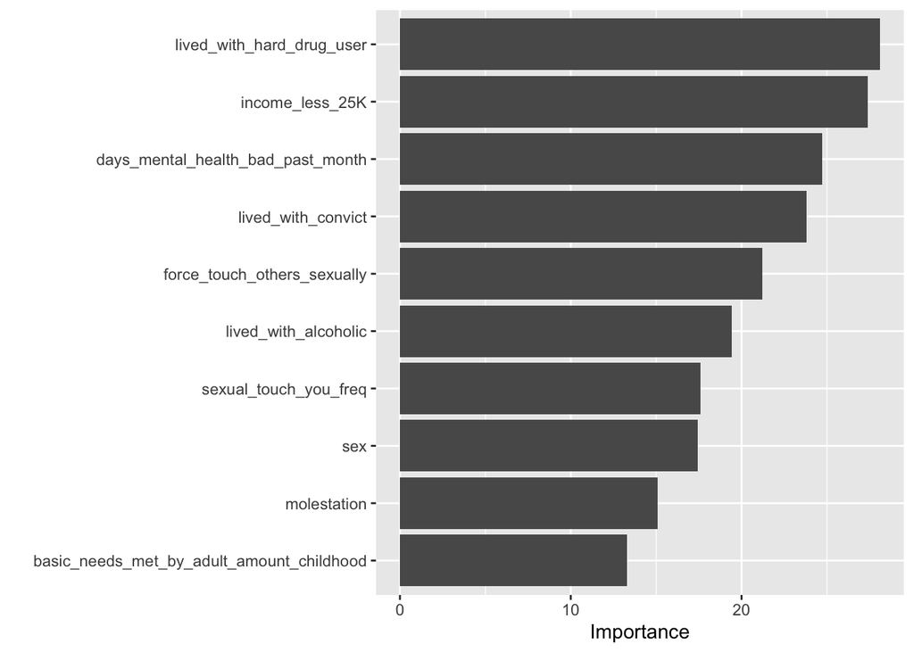

```r
# plot most important predictors
brfss.rf.predicted.nocrossval |>
  extract_fit_engine() |>
  vip()
```

```r
# calculate AUC without cross validation
roc_auc(brfss.rf.pred.values.nocrossval, truth, .pred_0)
```

```
# A tibble: 1 × 3
  .metric .estimator .estimate
  <chr>   <chr>          <dbl>
1 roc_auc binary         0.753
```

```r
# calculate AUC with cross validation
brfss.rf.pred.values.crossval |>
  collect_predictions() |>
  roc_auc(smoking, .pred_0)
```

```
# A tibble: 1 × 3
  .metric .estimator .estimate
  <chr>   <chr>          <dbl>
1 roc_auc binary         0.646
```

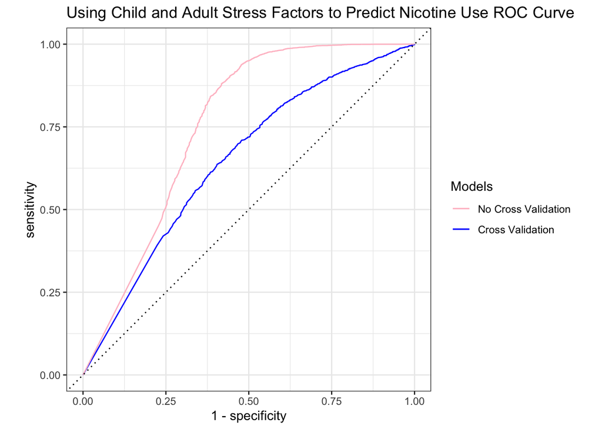

```r
# make plot input without cross validation
brfss.rf.plot_input.nocrossval <- brfss.rf.pred.values.nocrossval |>
  roc_curve(truth, .pred_0)

# make plot input with cross validation
brfss.rf.plot_input.crossval <- brfss.rf.pred.values.crossval |>
  collect_predictions() |>
  roc_curve(smoking, .pred_0)

# plot ROC curve
brfss.rf.pred.values.crossval |>
  collect_predictions() |>
  roc_curve(smoking, .pred_0) |>
  ggplot(aes(x = 1-specificity, y = sensitivity)) +
  geom_path(data=brfss.rf.plot_input.crossval,aes(color='Cross Validation')) +
  geom_path(data=brfss.rf.plot_input.nocrossval,aes(color='No Cross Validation')) +
  geom_abline(lty = 3) +
  coord_equal() +
  labs(title='Using Child and Adult Stress Factors to Predict Nicotine Use ROC Curve') +
  theme_bw() +
  scale_color_manual(name='Models',
                     breaks=c('No Cross Validation', 'Cross Validation'),
                     values=c('No Cross Validation'='pink', 'Cross Validation'='blue'))
```

```r
# look at logistic regression results
modelsummary(list("Sex"=sex_glm,
                  "Mental Health"=mental_health_glm,
                  "Socioeconomic Status" = income_less_25K_glm,
                  "Caregiver Status" = caregiver_glm,
                  "Lived with Someone who was Depressed, Mentally Ill or Suicidal as a Child" = lived_with_depressed_mentally_ill_or_suicidial_glm,
                  "Lived with an Alcoholic or Problem Drinker as a Child" = lived_with_alcoholic_glm,
                  "Lived with an Illicit Substance User or Prescription Drug Abuser as a Child" = lived_with_hard_drug_user_glm,
                  "Lived with Someone who was Incarcerated as a Child" = lived_with_convict_glm,
                  "Parents Separated or Divorced as a Child" = parents_separated_or_divorced_glm,
                  "Physical Abuse as a Child" = parents_hurt_you_freq_glm,
                  "Sweared at by Parents as a Child" = parents_swear_at_you_freq_glm,
                  "Touched Sexually as a Child" = sexual_touch_you_freq_glm,
                  "Forced to Touch Another Individual Sexually as a Child" = force_touch_others_sexually_glm,
                  "Forced to Have Sex as a Child" = force_sex_freq_glm,
                  "All Forms of Molestation as a Child" = molestation_glm,
                  "Basic Needs Met by an Adult as a Child" = basic_needs_met_by_adult_amount_childhood_glm),
             coef_omit = "Intercept",
             shape='rcollapse',
             statistic = c("p-value = {p.value}"),
             estimate = "odds ratio = {estimate}",
             exponentiate = T,
             coef_rename = coef_rename,
             gof_omit="IC|Log|RMSE")
```

|  | (1) |
| --- | --- |
| *Sex* |  |
| Sex | odds ratio = 1.467 |
|  | p-value = <0.001 |
| *Mental Health* |  |
| Days Mental Health Bad Past Month | odds ratio = 1.040 |
|  | p-value = <0.001 |
| *Socioeconomic Status* |  |
| Income less 25k | odds ratio = 2.457 |
|  | p-value = <0.001 |
| *Caregiver Status* |  |
| Caregiver Past Month | odds ratio = 1.068 |
|  | p-value = 0.381 |
| *Lived with Someone who was Depressed, Mentally Ill or Suicidal as a Child* |  |
| Lived with Depressed Mentally Ill or Suicidial | odds ratio = 1.567 |
|  | p-value = <0.001 |
| *Lived with an Alcoholic or Problem Drinker as a Child* |  |
| Lived with Alcoholic | odds ratio = 1.908 |
|  | p-value = <0.001 |
| *Lived with an Illicit Substance User or Prescription Drug Abuser as a Child* |  |
| Lived with Hard Drug User | odds ratio = 2.369 |
|  | p-value = <0.001 |
| *Lived with Someone who was Incarcerated as a Child* |  |
| Lived with Convict | odds ratio = 2.627 |
|  | p-value = <0.001 |
| *Parents Separated or Divorced as a Child* |  |
| Parents Separated or Divorced | odds ratio = 2.122 |
|  | p-value = <0.001 |
| *Physical Abuse as a Child* |  |
| Parents Hurt you Freq | odds ratio = 1.726 |
|  | p-value = <0.001 |
| *Sweared at by Parents as a Child* |  |
| Parents Swear at you Freq | odds ratio = 1.480 |
|  | p-value = <0.001 |
| *Touched Sexually as a Child* |  |
| Sexual Touch you Freq | odds ratio = 1.511 |
|  | p-value = <0.001 |
| *Forced to Touch Another Individual Sexually as a Child* |  |
| Force Touch Others Sexually | odds ratio = 1.517 |
|  | p-value = <0.001 |
| *Forced to Have Sex as a Child* |  |
| Force Sex Freq | odds ratio = 2.049 |
|  | p-value = <0.001 |
| *All Forms of Molestation as a Child* |  |
| Molestation | odds ratio = 1.528 |
|  | p-value = <0.001 |
| *Basic Needs Met by an Adult as a Child* |  |
| Basic Needs Met by Adult Amount Childhood | odds ratio = 0.777 |
|  | p-value = <0.001 |
| Num.Obs. | 6741 |

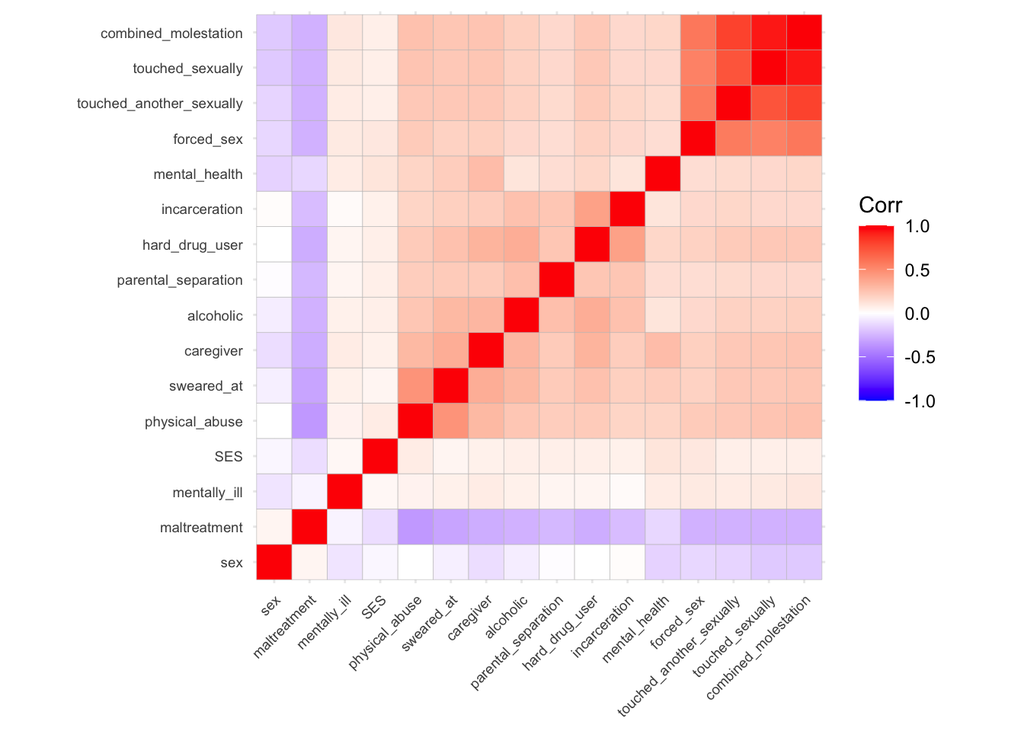

```r
# look at correlation matrix
ggcorrplot(predictor_cor, hc.order = TRUE) +
  theme(axis.text.x=element_text(size=7), axis.text.y=element_text(size=7))
```

### Conclusion

In univariate logistic regressions, all predictors were significantly associated with nicotine use status except for caregiver status, replicating what is seen in the literature. Having lived with someone who was incarcerated as a child has the highest odds ratio, such that individuals who experienced this are 2.6x more likely to use nicotine as an adult.

Additionally, most predictors are not strongly correlated. The only predictors that are strongly positively correlated are different forms of molestation, which makes sense. This indicates that individuals that experienced one form of molestation have a high likelihood of experiencing another form of molestation. Thus, it is likely that these predictors are interacting in the random forest model.

I would have expected the random forest model to perform better but the study has some limitations. First, there is no way to validate whether people answered the survey questions truthfully. Additionally, annual household income < $25,000 may not be the best predictor of socioeconomic status because the cost of living varies across the country and it does not account for how many people the income is supporting. However, this predictor was the second most important predictor in the study. Last, I could only include 16 predictors in order to maintain a high sample size. A dataset with less missingness would have allowed for more predictors, which may have improved model performance.

### References

1. Diseases and death. *Centers for Disease Control and Prevention* (2022). Available at: https://www.cdc.gov/tobacco/data_statistics/fact_sheets/fast_facts/diseases-and-death.html#:~:text=Smoking%20is%20the%20leading%20cause%20of%20preventable%20death.&text=This%20is%20about%20one%20in,or%201%2C300%20deaths%20every%20day. (Accessed: 30th October 2023)
2. U.S. Department of Health and Human Services. *The Health Consequences of Smoking-50 Years of Progress: A Report of the Surgeon General* (Department of Health and Human Services, Centers for Disease Control and Prevention, National Center for Chronic Disease Prevention and Health Promotion, Office on Smoking and Health, 2014).
3. Jha, P. *et al.* 21st-century hazards of smoking and benefits of cessation in the United States. *New England Journal of Medicine* **368,** 341–350 (2013).
4. Slopen, N. *et al.* Psychosocial stress and cigarette smoking persistence, cessation, and relapse over 9–10 years: A prospective study of middle-aged adults in the United States. *Cancer Causes & Control* **24,** 1849–1863 (2013).
5. Pathak, R., Dwivedi, S., Agarwalla, R. & Ali, W. The intergenerational transmission of tobacco habit: Role of parents and the family. *Journal of Family Medicine and Primary Care* **5,** 373–377 (2016).
6. Eve, S. G. *et al.* Relationship between child abuse and adult smoking. *Int J Psychiatry Med* **39,** 417–426 (2009).
7. Kristman-Valente, A. N., Brown, E. C. & Herrenkohl, T. I. Child physical and sexual abuse and cigarette smoking in adolescence and adulthood. *Journal of Adolescent Health* **53,** 533–538 (2013).
8. Taha, F., Galea, S., Hien, D. & Goodwin, R. D. Childhood maltreatment and the persistence of smoking: A longitudinal study among adults in the US. *Child Abuse & Neglect* **38,** 1995–2006 (2014).
9. Davis, L. & Shlafer, R. J. Substance use among youth with currently and formerly incarcerated parents. *Children of Incarcerated Parents* **87,** 42–57 (2018).
10. Lindström, M. & Rosvall, M. Parental separation/divorce in childhood and tobacco smoking in adulthood: A population-based study. *Scandinavian Journal of Public Health* **48,** 657–666 (2019).